# Explore and Summarize Data by KUNAL MANIK

# Data Set (Referred by Udacity)- *Loan Data from Prosper*

# Summary of the Data Set

*“This data set contains 113,937 loans with 81 variables on each loan, including loan amount, borrower rate (or interest rate), current loan status, borrower income, borrower employment status, borrower credit history, and the latest payment information.”* - as stated on discription.

```
## [1] 113937     81
```

Following is the list of all the 81 variables:

```
##  [1] "ListingKey"
##  [2] "ListingNumber"
##  [3] "ListingCreationDate"
##  [4] "CreditGrade"
##  [5] "Term"
##  [6] "LoanStatus"
##  [7] "ClosedDate"
##  [8] "BorrowerAPR"
##  [9] "BorrowerRate"
## [10] "LenderYield"
## [11] "EstimatedEffectiveYield"
## [12] "EstimatedLoss"
## [13] "EstimatedReturn"
## [14] "ProsperRating..numeric."
## [15] "ProsperRating..Alpha."
```

[output cut: 66 more lines]

Variables:

```
## 'data.frame':    113937 obs. of  81 variables:
##  $ ListingKey                         : chr  "1021339766868145413AB3B" "10273602499503308B223C1" "0EE9337825851032864889A" "0EF5356002482715299901A" ...
##  $ ListingNumber                      : int  193129 1209647 81716 658116 909464 1074836 750899 768193 1023355 1023355 ...
##  $ ListingCreationDate                : chr  "2007-08-26 19:09:29.263000000" "2014-02-27 08:28:07.900000000" "2007-01-05 15:00:47.090000000" "2012-10-22 11:02:35.010000000" ...
##  $ CreditGrade                        : chr  "C" "" "HR" "" ...
##  $ Term                               : int  36 36 36 36 36 60 36 36 36 36 ...
##  $ LoanStatus                         : chr  "Completed" "Current" "Completed" "Current" ...
##  $ ClosedDate                         : chr  "2009-08-14 00:00:00" "" "2009-12-17 00:00:00" "" ...
##  $ BorrowerAPR                        : num  0.165 0.12 0.283 0.125 0.246 ...
##  $ BorrowerRate                       : num  0.158 0.092 0.275 0.0974 0.2085 ...
##  $ LenderYield                        : num  0.138 0.082 0.24 0.0874 0.1985 ...
##  $ EstimatedEffectiveYield            : num  NA 0.0796 NA 0.0849 0.1832 ...
##  $ EstimatedLoss                      : num  NA 0.0249 NA 0.0249 0.0925 ...
##  $ EstimatedReturn                    : num  NA 0.0547 NA 0.06 0.0907 ...
##  $ ProsperRating..numeric.            : int  NA 6 NA 6 3 5 2 4 7 7 ...
```

[output cut: 67 more lines]

# Univariate Plots Section

```
## [1] "2005-11-09 20:44:28.847000000" "2014-03-10 12:20:53.760000000"
```

I’ve noticed that a few variables are valid only for loans created post July 2009. Thus, we calculate percentage/number of those loans that were created before the mentioned date.

**Loans created before July 2009**

```
## Number of loans before July 1st, 2009
## FALSE  TRUE
## 84853 29084
```

```
## Percentage of loans before July 1st, 2009
##    FALSE     TRUE
## 74.47361 25.52639
```

25.52639% loans don’t have values for a few parameters.

**Distribution of loans**

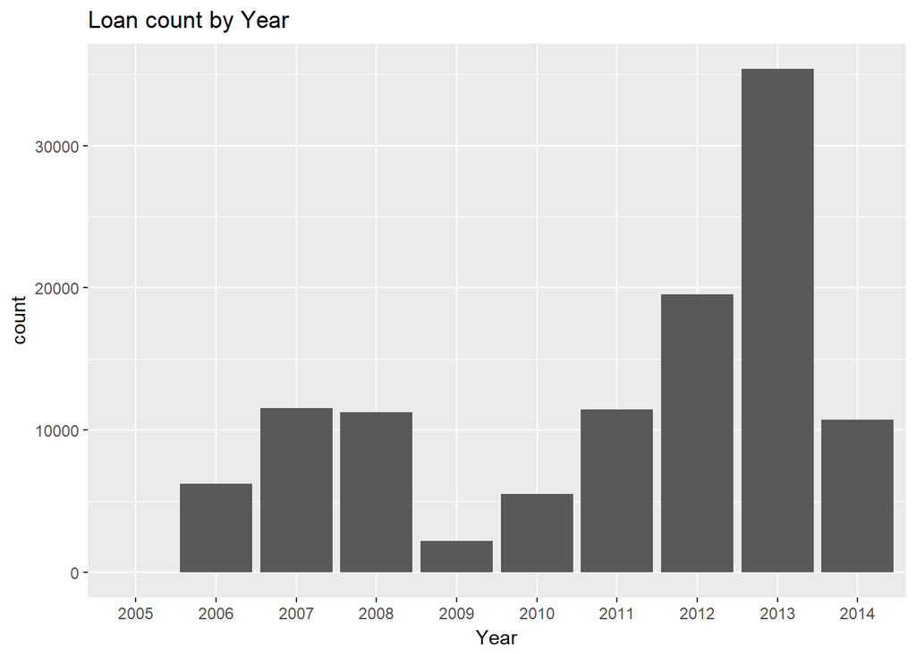

The number of loansalmost doubled from 2006 to 2007, then remained almost equal (a little drop in numbers) in 2008 and suffered a drastic decrease in numbers in 2009. The numbers looked solid post 2012 especially in year 2013, the highest for the data available.

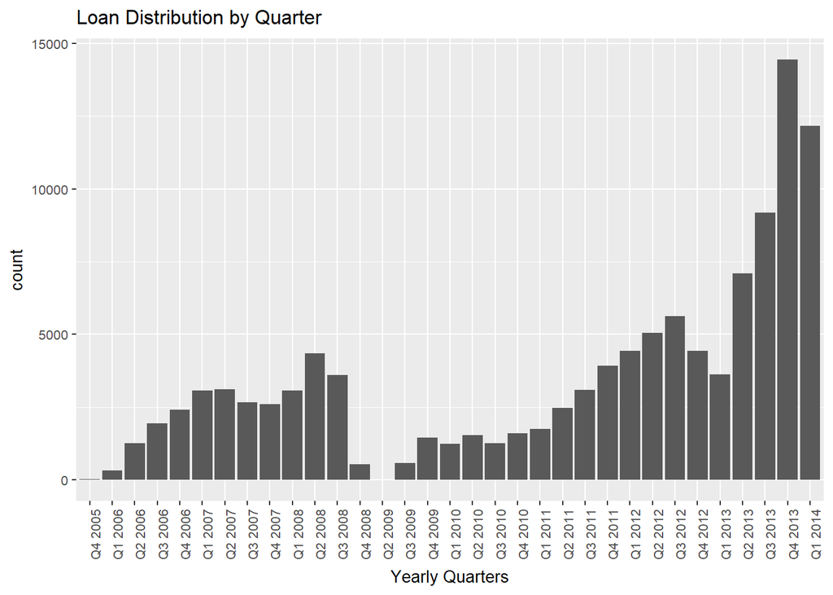

**Borrowing Amount**

```
##    Min. 1st Qu.  Median    Mean 3rd Qu.    Max.
##    1000    4000    6500    8337   12000   35000
```

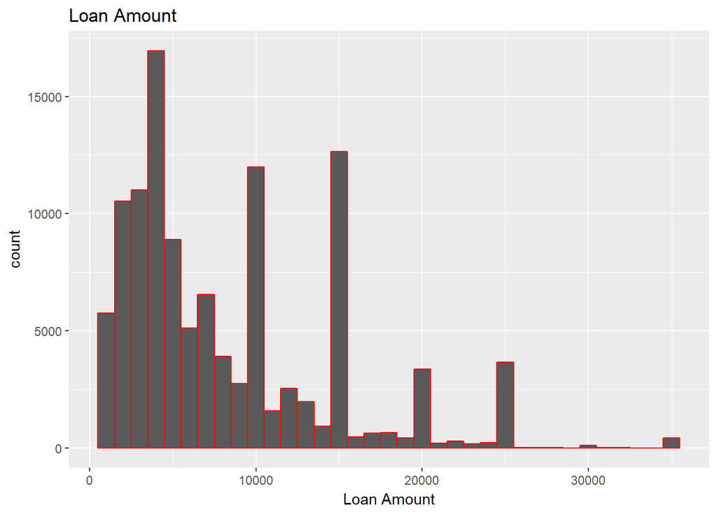

**Most frequent loan term**

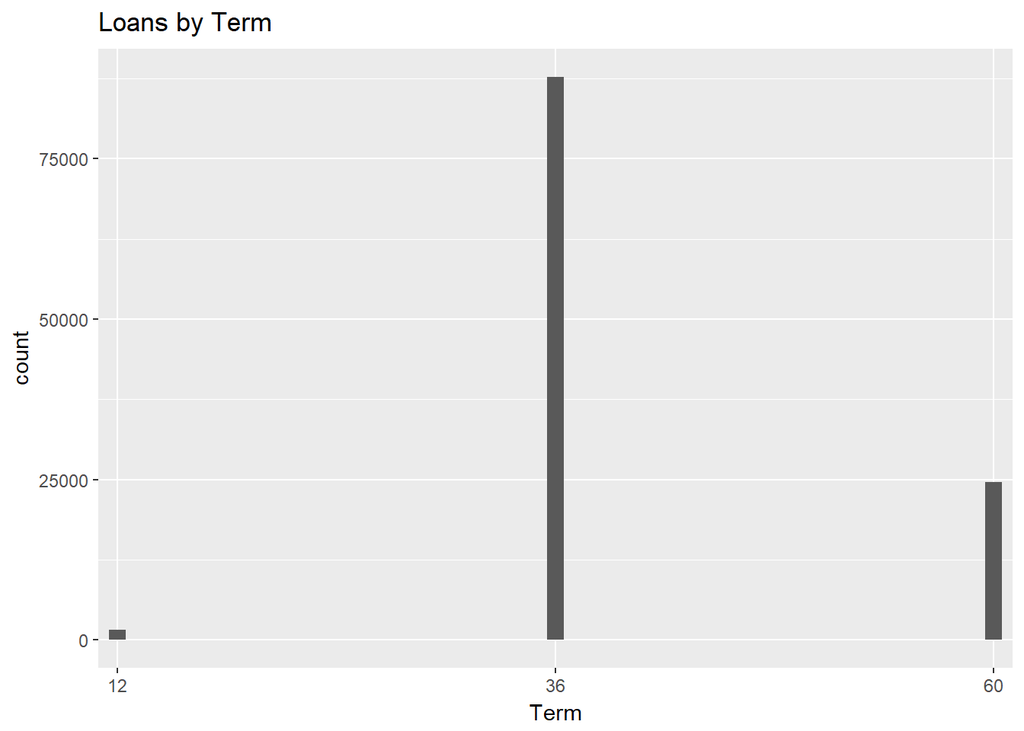

```
##
##    12    36    60
##  1614 87778 24545
```

```
##    Min. 1st Qu.  Median    Mean 3rd Qu.    Max.
##   12.00   36.00   36.00   40.83   36.00   60.00
```

The most frequent term is 36 months (3 years).

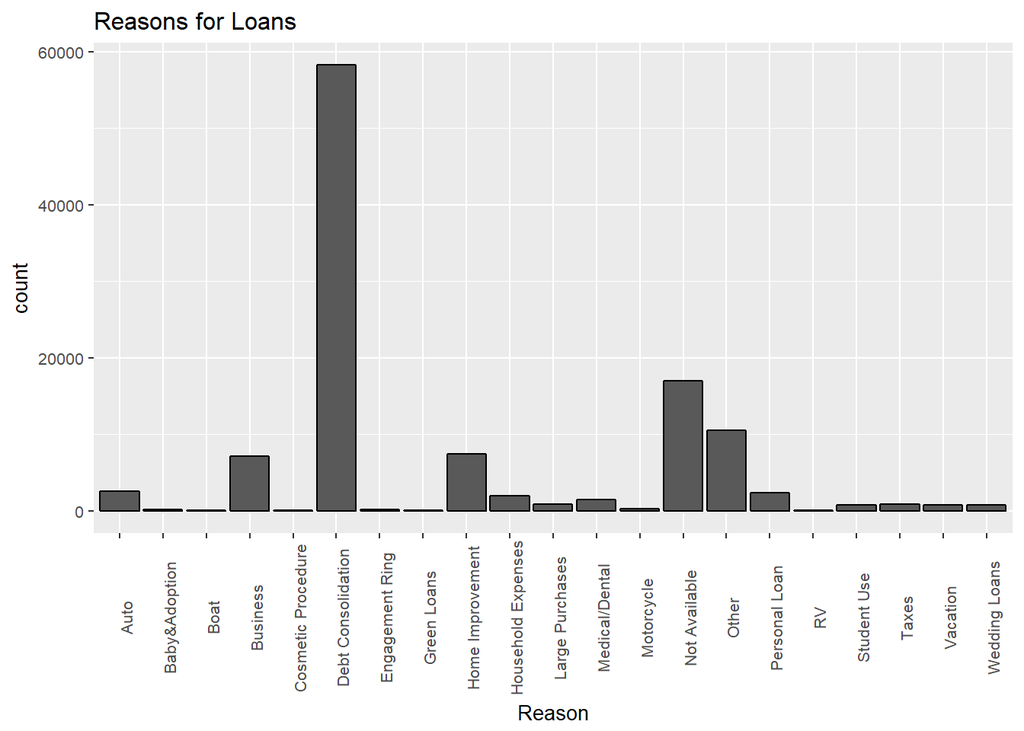

Debt Consolidation is the reason for maximum number of loans.

```
##
##  2005  2006  2007  2008  2009  2010  2011  2012  2013  2014
##    23  6213 10709     0     0     0     9     4     6     1
```

Most of the loans without any Listing category were created in 2006 and 2007, 6213 and 10709 respectively. Only 20 loans were created from 2011 to 2014 and 23 were created in 2005 (with the data that is available).

**Monthly Loan Payment**

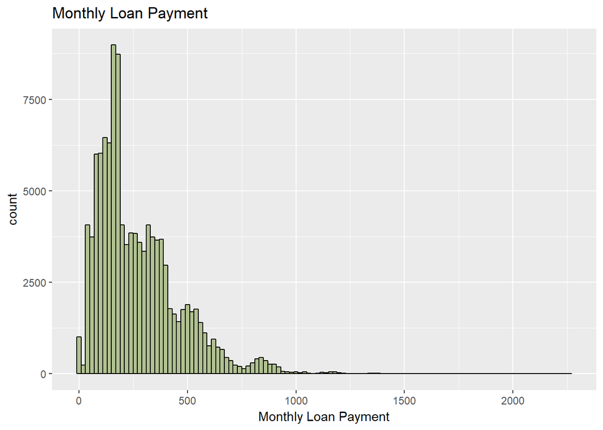

```
##    Min. 1st Qu.  Median    Mean 3rd Qu.    Max.
##     0.0   131.6   217.7   272.5   371.6  2251.5
```

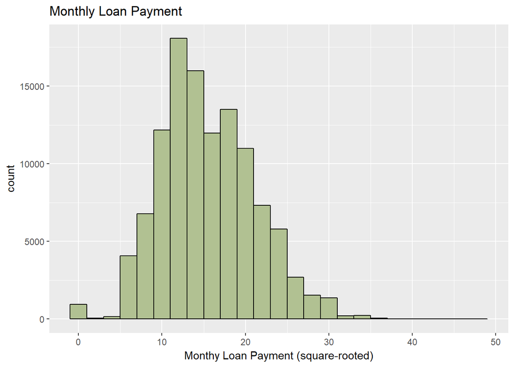

Distribution appears to be “Normal”.

**Annual Income of Borrowers**

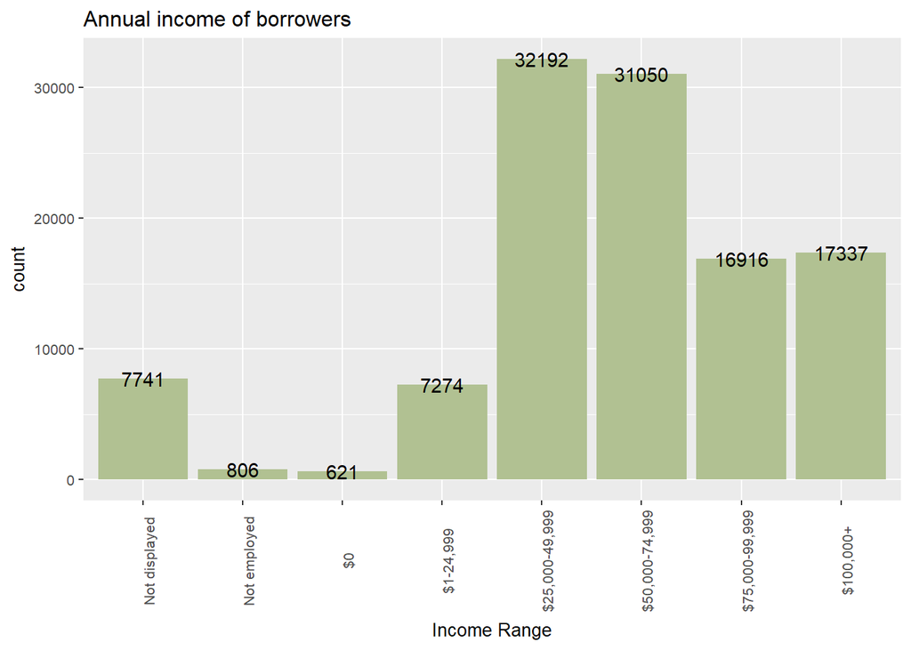

Most of the borrowers have annual income falling in the range of 25,000 to 74,999 Dollars.

**Distribution of Monthly Debt**

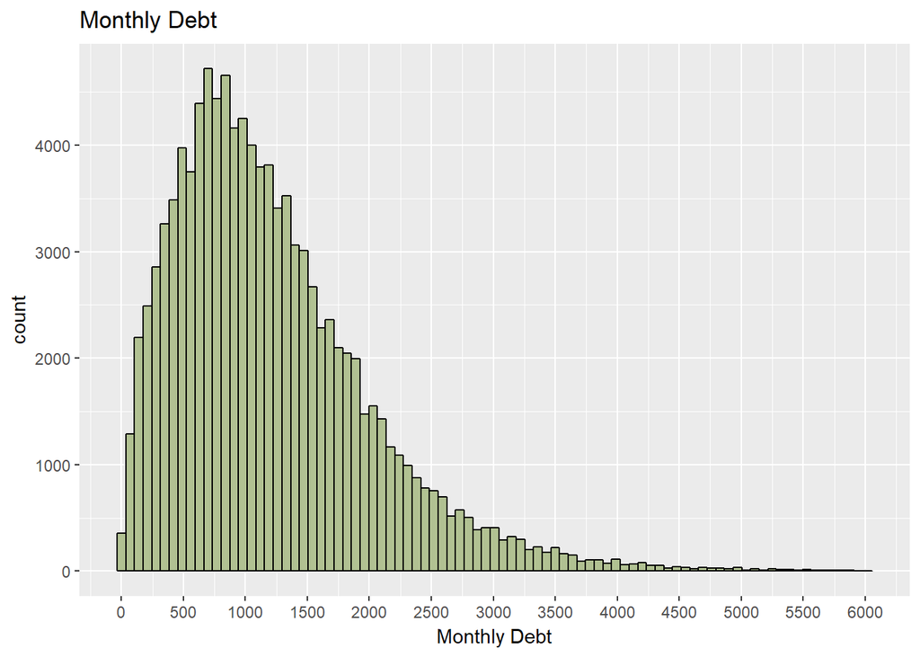

```
##     Min.  1st Qu.   Median     Mean  3rd Qu.     Max.     NA's
##      0.0    637.5   1061.5   1224.9   1622.4 171004.2     8554
```

```
##    Min. 1st Qu.  Median    Mean 3rd Qu.    Max.
##     0.0   637.5  1059.2  1212.1  1619.2  6000.0
```

The graph appears to be skewed.

**Employment Status of the Borrowers**

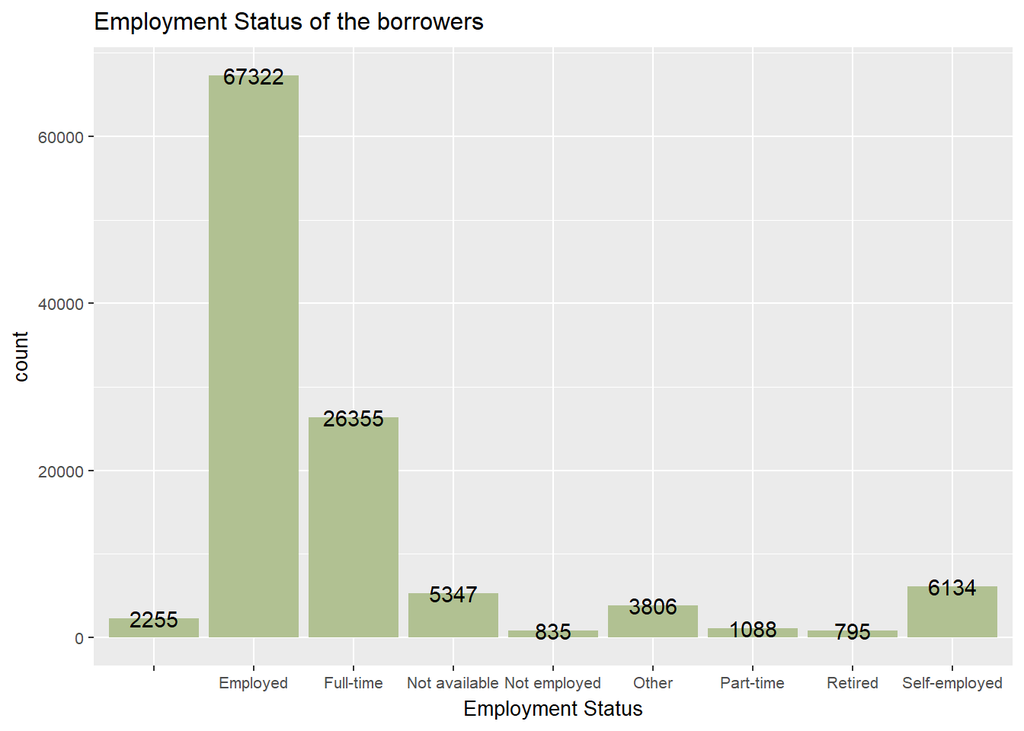

```
##
##   employed unemployed
##     100899      13038
```

**Employment Status - Duration**

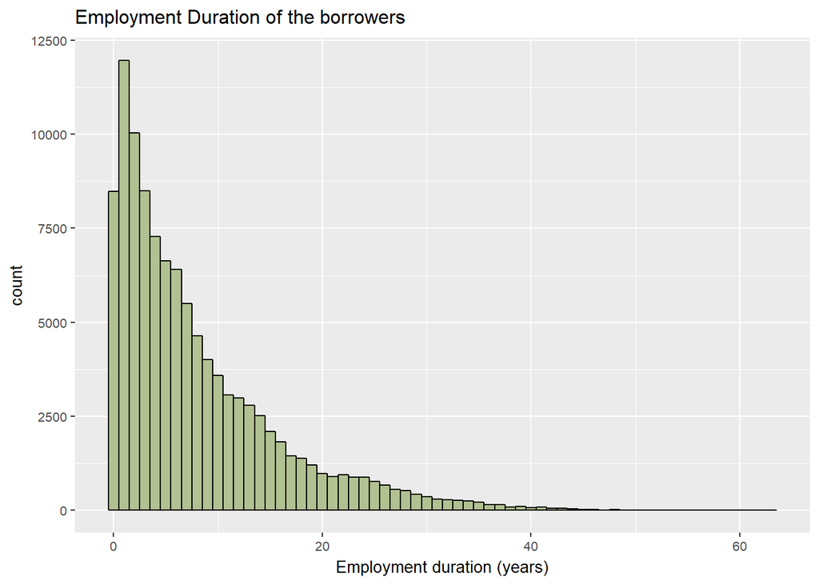

People with longer duration of employment are less likely to apply for a loan.

**Occupation of Borrowers**

```
## # A tibble: 10 x 2
##    Occupation               count
##    <chr>                    <int>
##  1 Professional             13628
##  2 Computer Programmer       4478
##  3 Executive                 4311
##  4 Teacher                   3759
##  5 Administrative Assistant  3688
##  6 Analyst                   3602
##  7 Sales - Commission        3446
##  8 Accountant/CPA            3233
##  9 Clerical                  3164
## 10 Sales - Retail            2797
```

28617 loans have Other as value for occupation.

```
##
## 2005 2006 2007 2008 2009 2010 2011 2012 2013 2014
##   23 2183   49    0    0    0    0    0  811  522
```

```
##
##           Full-time     Other
##      2255         1      1332
```

No Occupation exists for loans created between 2005 and 2007, no employment status available. Employment status is “Other” for years 2013 to 2014 for the given numbers above.

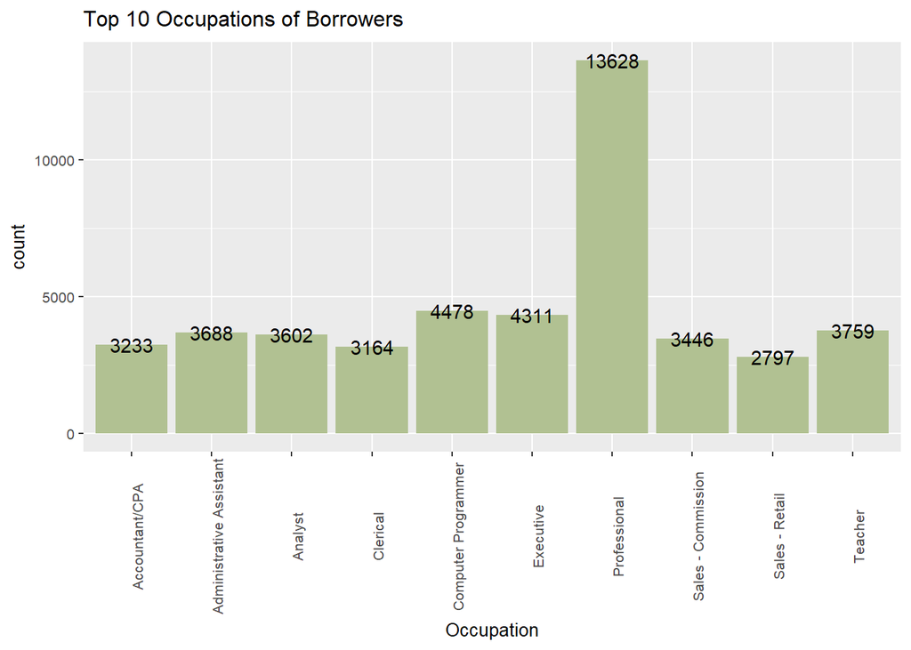

**Borrowers’ States**

```
##
## 2005 2006 2007 2008 2009 2010 2011 2012 2013 2014
##   23 3137 2332   23    0    0    0    0    0    0
```

All of the loans without any borrower state were available before 2009.

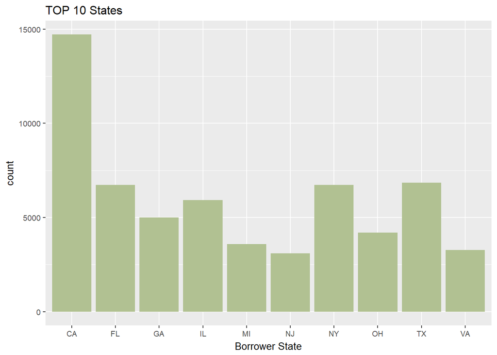

**Prosper Ratings for the borrowers**

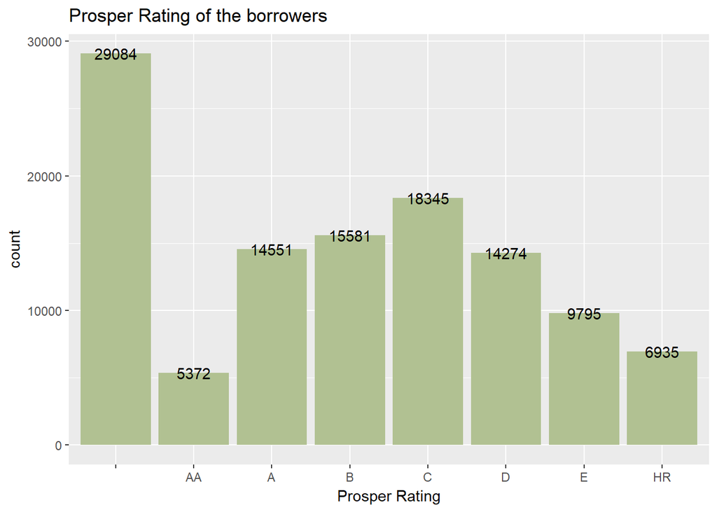

Most of the borrowers have prosper rating between A and D. AA is the most rare Prosper Rating

No Prosper Rating is available for the loans before July 2009.

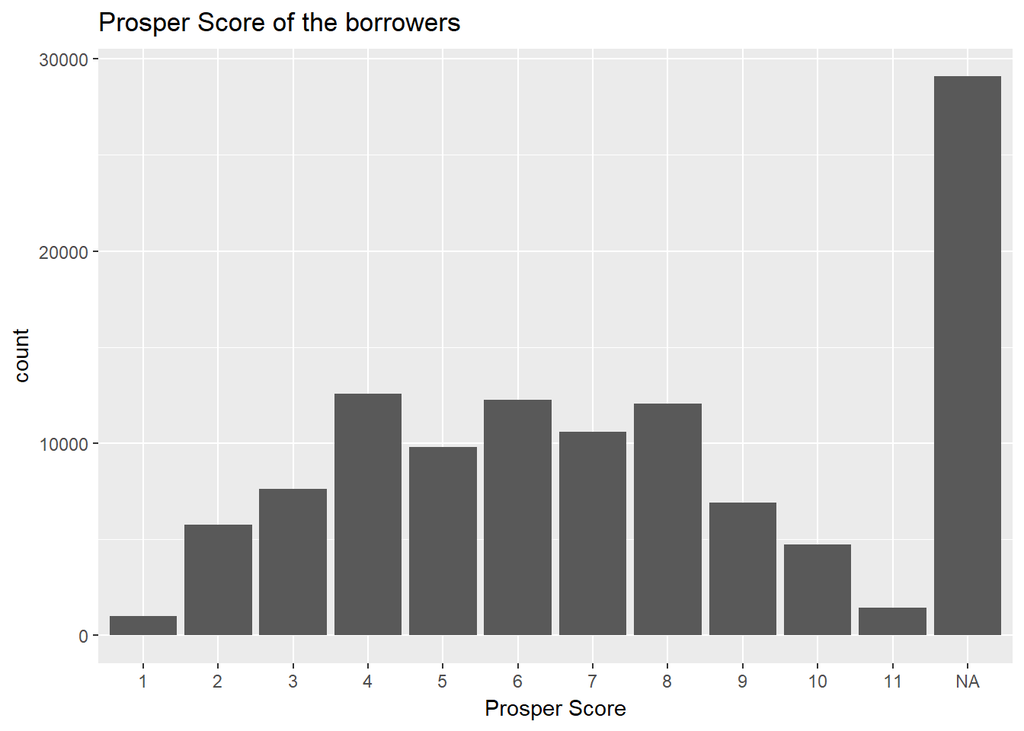

```
##    Min. 1st Qu.  Median    Mean 3rd Qu.    Max.    NA's
##    1.00    4.00    6.00    5.95    8.00   11.00   29084
```

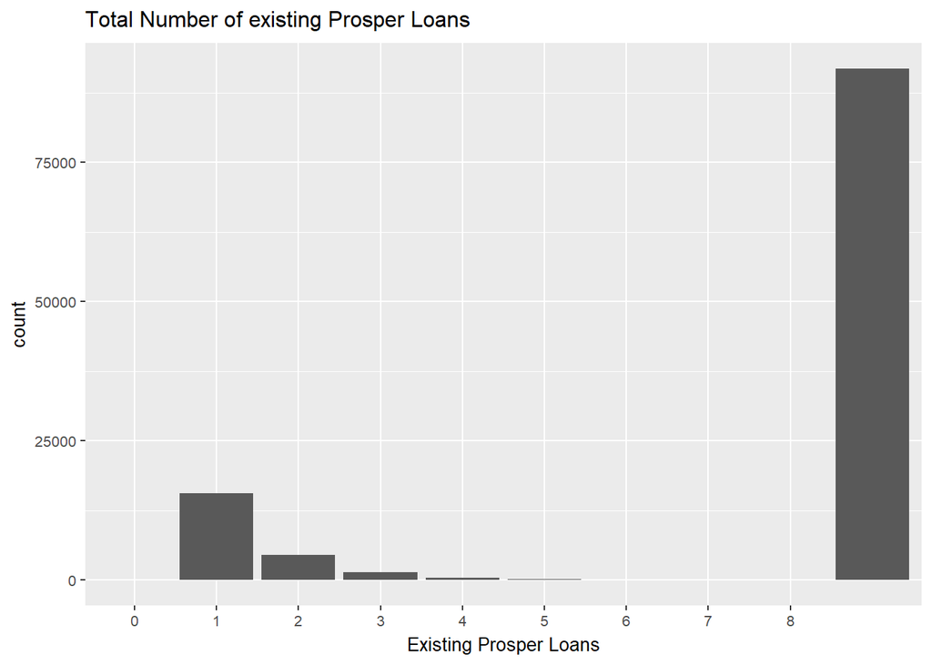

```
##    Min. 1st Qu.  Median    Mean 3rd Qu.    Max.    NA's
##    0.00    1.00    1.00    1.42    2.00    8.00   91852
```

**Investors**

```
##    Min. 1st Qu.  Median    Mean 3rd Qu.    Max.
##    1.00    2.00   44.00   80.48  115.00 1189.00
```

There is a significant difference in 3rd Qu. and Max. value. Thus, we can conclude that the Max value is an outlier.

**Loans with Recommendations**

```
##
##      0      1      2      3      4      5      6      7      8      9
## 109678   3516    568    108     26     14      4      5      3      6
##     14     16     18     19     21     24     39
##      1      2      2      1      1      1      1
```

109678 loans do not have any recommendation.

**Lender Yield on the Loans**

```
##    Min. 1st Qu.  Median    Mean 3rd Qu.    Max.
## -0.0100  0.1242  0.1730  0.1827  0.2400  0.4925
```

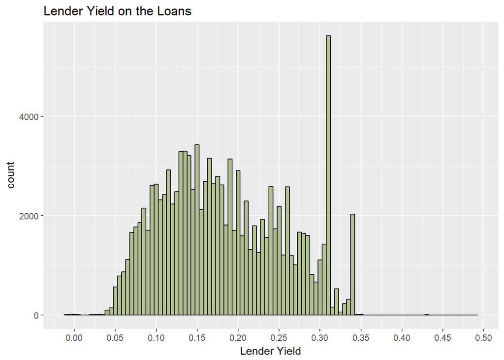

# What is the structure of your dataset?

```
## [1] 113937     85
```

This dataset contains 113937 loans with 85 variables.

# What is/are the main feature(s) of interest in your dataset?

In my analysis the main features of interest are:

Number of investors, Borrower rate, Creation Date Listing helped me to understand more about the Prosper dataset and their business along with the distribution of loans over the years.

Prosper Score, Income Range, Loan amount, Loan Category also contribute to the major interests.

# What other features in the dataset do you think will help support your investigation into your feature(s) of interest?

Other variables that can help me to support my investigation are Credist Score, Debt To Income Ratio, Prosper Rating, Occupation, Employment Status and Employment Duration.

# Did you create any new variables from existing variables in the dataset?

I created the following variables -> CreationYearList, MonthlyDebt, StateOfEmployment, CategoryNameList.

# Of the features you investigated, were there any unusual distributions? Did you perform any operations on the data to tidy, adjust, or change the form of the data? If so, why did you do this?

The knowledge of 2008-09 Economic Crisis helped me to relate the fall in the graph values and why was there a sudden dip in the plots.

I adjusted CreationYearList variable as a factor that would appear discrete.

# Bivariate Plots Section

## Number of Investors

**Relation between Prosper Score and Number of Investors**

```
## Number of Loans by Prosper Score
##     1     2     3     4     5     6     7     8     9    10    11
##   992  5766  7642 12595  9813 12278 10597 12053  6911  4750  1456
```

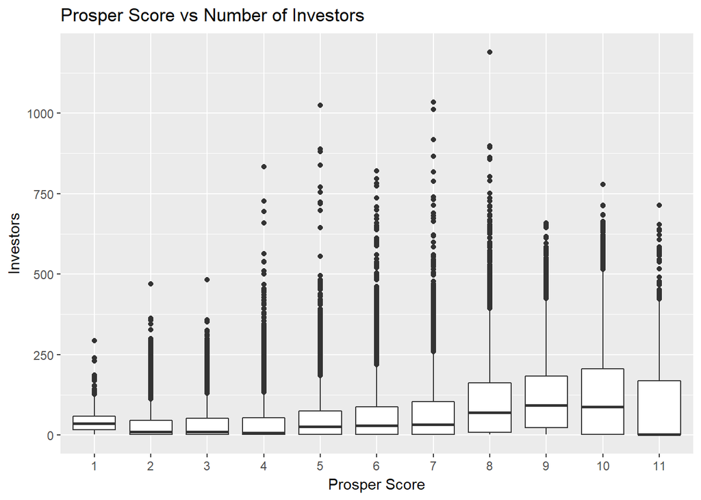

Plotting Mean Investors value for Prosper Score…

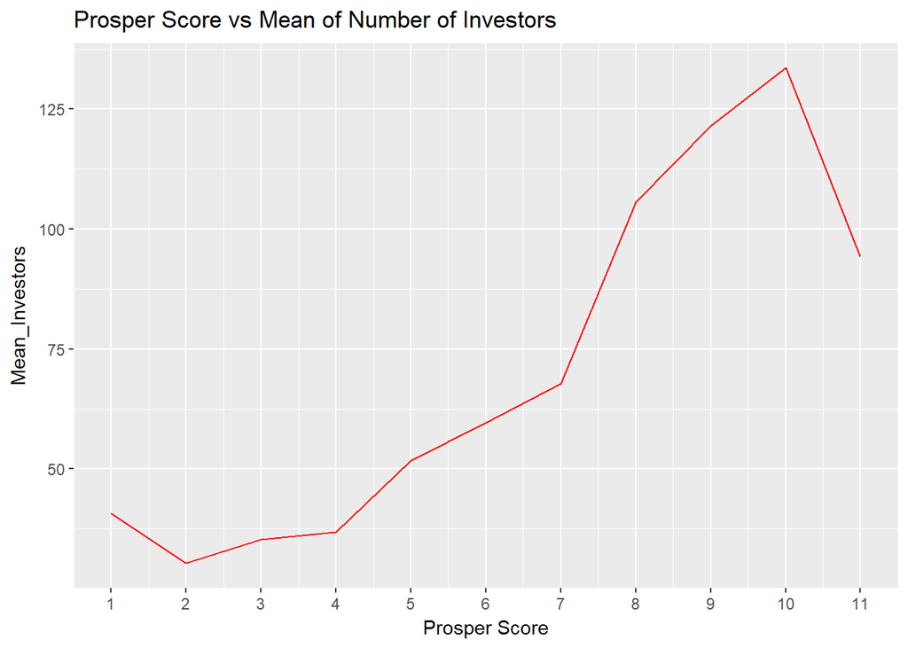

The number of investors is grows with prosper score. The peak is reached when prosper score is equal to 10. In this case subset of all loans created after July 1st 2009 is used since Prosper Score was not available for loans created prior to that date.

**Relationship between Original Loan Amount and Number of Investors**

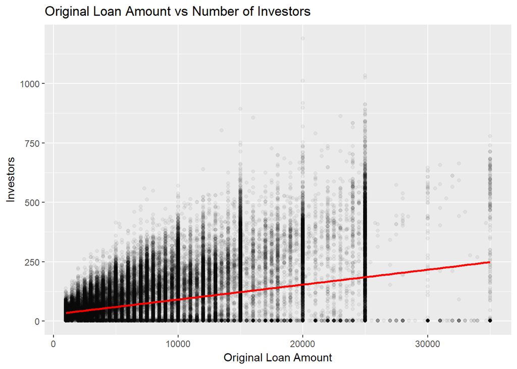

Larger loans have more investors.

**Relation between Number of Investors and Number of Prosper Loans.**

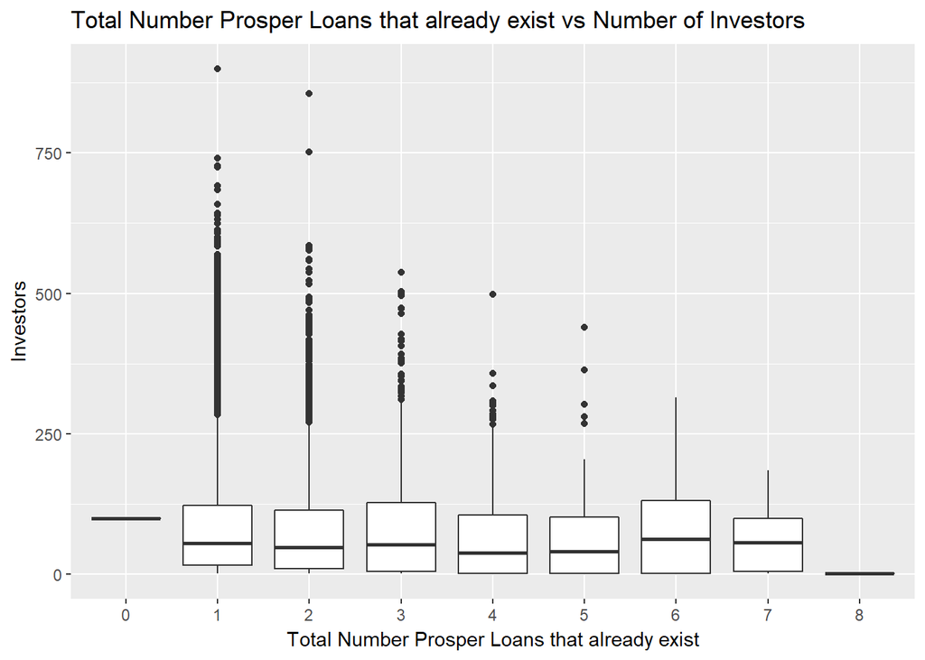

```
##    Min. 1st Qu.  Median    Mean 3rd Qu.    Max.    NA's
##    0.00    1.00    1.00    1.42    2.00    8.00   91852
```

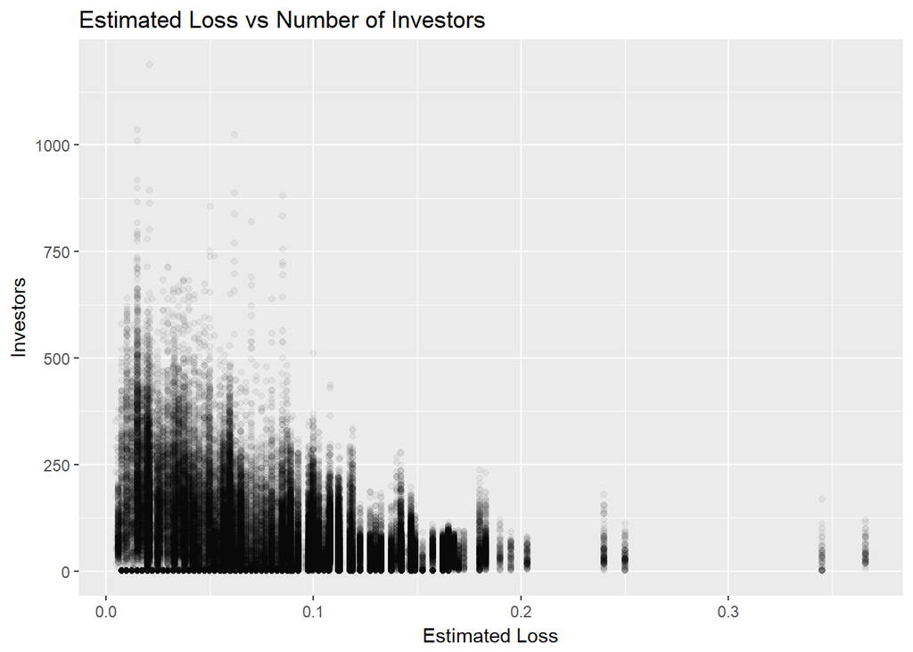

```
##
##  Pearson's product-moment correlation
##
## data:  loan_df$EstimatedLoss and loan_df$Investors
## t = -83.482, df = 84851, p-value < 2.2e-16
## alternative hypothesis: true correlation is not equal to 0
## 95 percent confidence interval:
##  -0.2817071 -0.2692716
## sample estimates:
##        cor
## -0.2755009
```

## Loan Amount Analysis

**Variation in Borrows Loan Amount**

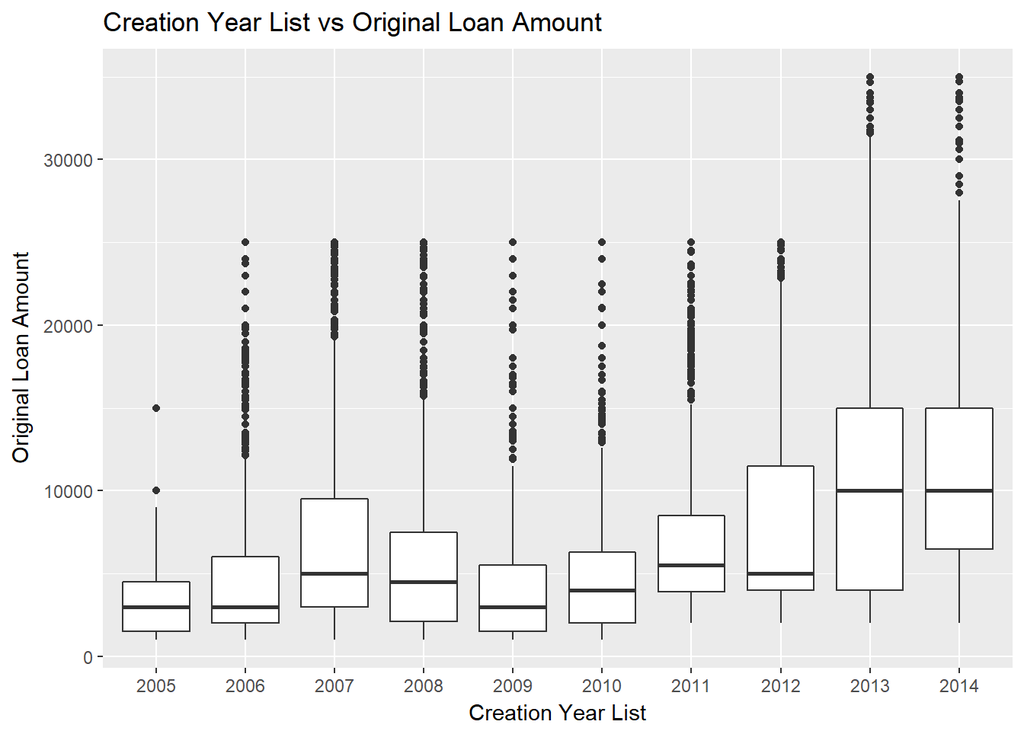

```
## loan_df$CreationYearList: 2005
##    Min. 1st Qu.  Median    Mean 3rd Qu.    Max.
##    1000    1500    3000    3856    4500   15000
## --------------------------------------------------------
## loan_df$CreationYearList: 2006
##    Min. 1st Qu.  Median    Mean 3rd Qu.    Max.
##    1000    2000    3001    4845    6000   25000
## --------------------------------------------------------
## loan_df$CreationYearList: 2007
##    Min. 1st Qu.  Median    Mean 3rd Qu.    Max.
##    1000    3000    5000    7067    9500   25000
## --------------------------------------------------------
## loan_df$CreationYearList: 2008
##    Min. 1st Qu.  Median    Mean 3rd Qu.    Max.
##    1000    2100    4500    5965    7500   25000
## --------------------------------------------------------
## loan_df$CreationYearList: 2009
##    Min. 1st Qu.  Median    Mean 3rd Qu.    Max.
##    1000    1500    3000    4393    5500   25000
## --------------------------------------------------------
## loan_df$CreationYearList: 2010
##    Min. 1st Qu.  Median    Mean 3rd Qu.    Max.
##    1000    2000    4000    4842    6300   25000
## --------------------------------------------------------
## loan_df$CreationYearList: 2011
##    Min. 1st Qu.  Median    Mean 3rd Qu.    Max.
##    2000    3907    5500    6704    8500   25000
## --------------------------------------------------------
## loan_df$CreationYearList: 2012
##    Min. 1st Qu.  Median    Mean 3rd Qu.    Max.
##    2000    4000    5000    7877   11511   25000
## --------------------------------------------------------
## loan_df$CreationYearList: 2013
##    Min. 1st Qu.  Median    Mean 3rd Qu.    Max.
##    2000    4000   10000   10610   15000   35000
## --------------------------------------------------------
## loan_df$CreationYearList: 2014
##    Min. 1st Qu.  Median    Mean 3rd Qu.    Max.
##    2000    6500   10000   11915   15000   35000
```

Mean Loan amount fell deeply in 2009 (4393) and reached the top value in 2013-14; 10610 and 11920 respectively.

**Relation between Loan Amount and Term**

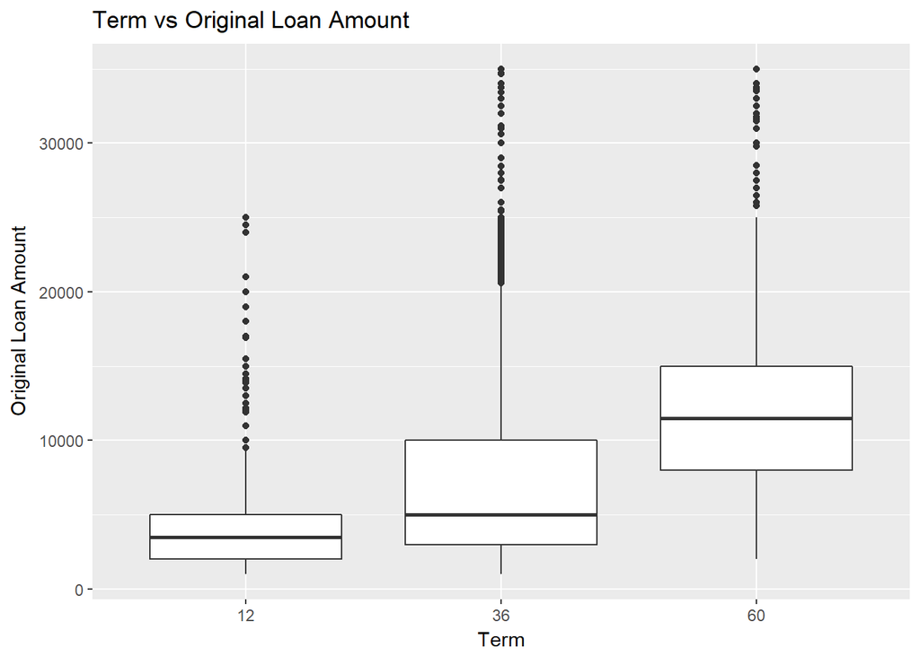

```
## loan_df$Term: 12
##    Min. 1st Qu.  Median    Mean 3rd Qu.    Max.
##    1000    2000    3500    4694    5000   25000
## --------------------------------------------------------
## loan_df$Term: 36
##    Min. 1st Qu.  Median    Mean 3rd Qu.    Max.
##    1000    3000    5000    7276   10000   35000
## --------------------------------------------------------
## loan_df$Term: 60
##    Min. 1st Qu.  Median    Mean 3rd Qu.    Max.
##    2000    8000   11500   12370   15000   35000
```

Loan amounts are larger for longer terms

**Relation between IncomeRange and Loan Amount**

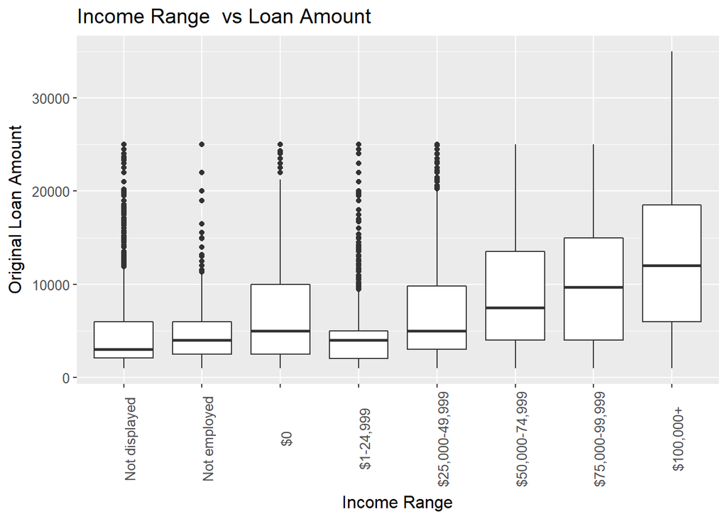

Larger loans tend to relate to larger incomes.

**Relationship between Employment Status and Loan Amount**

using StateOfEmployment for this plot.

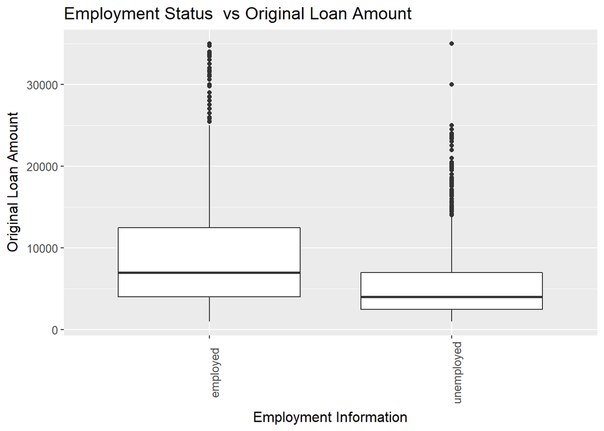

Employed people tend to borrow more money than unemployed people.

## Other Variables Analysis

**Monthly Debt vs Current Credit Lines**

Current Credit Lines

```
##    Min. 1st Qu.  Median    Mean 3rd Qu.    Max.    NA's
##    0.00    7.00   10.00   10.32   13.00   59.00    7604
```

MonthlyDebt

```
##     Min.  1st Qu.   Median     Mean  3rd Qu.     Max.     NA's
##      0.0    637.5   1061.5   1224.9   1622.4 171004.2     8554
```

[figure not shown]

```
##
##  Pearson's product-moment correlation
##
## data:  loan_df$CurrentCreditLines and loan_df$MonthlyDebt
## t = 168.12, df = 97901, p-value < 2.2e-16
## alternative hypothesis: true correlation is not equal to 0
## 95 percent confidence interval:
##  0.4684282 0.4781498
## sample estimates:
##       cor
## 0.4733034
```

As the number of credit lines increases, debt is increasing as well. We have positive correlation of 0.47.

# Bivariate Analysis

### Talk about some of the relationships you observed in this part of the investigation. How did the feature(s) of interest vary with other features in the dataset?

The number of investors increases when the prosper score is high, loan amount is high, borrowers have less existing prosper loans and estimated loss is less.

The lowest mean was $4393 in 2009 and the top mean value is in 2013-14 $10610 and $11920 respectively.

Higher loan amounts usually have longer term and they are related more to employed borrowers with larger incomes than unemployed ones.

### Did you observe any interesting relationships between the other features (not the main feature(s) of interest)?

I’ve observed that employed people borrow more money than the unemployed ones. Also, as the number of credit lines increases, debt increases as well.

### What was the strongest relationship you found?

The strongest relationship I found was between Number of Credit Lines and MonthlyDebt. The relation had positive correlation of 0.47.

# Multivariate Plots Section

**Borrower Rate / Loan Amount / Prosper Rating**

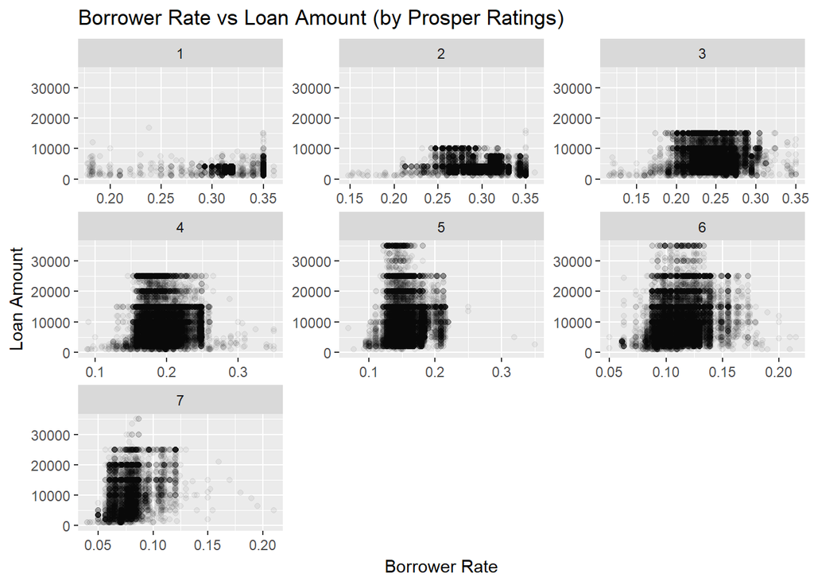

Loans with high Prosper Rating have low Borrower Rate. Borrowers with low Prosper Rating usually borrow lower amounts but with higher rate.

**Borrower Rate / Loan Amount / Prosper Rating by Income Range**

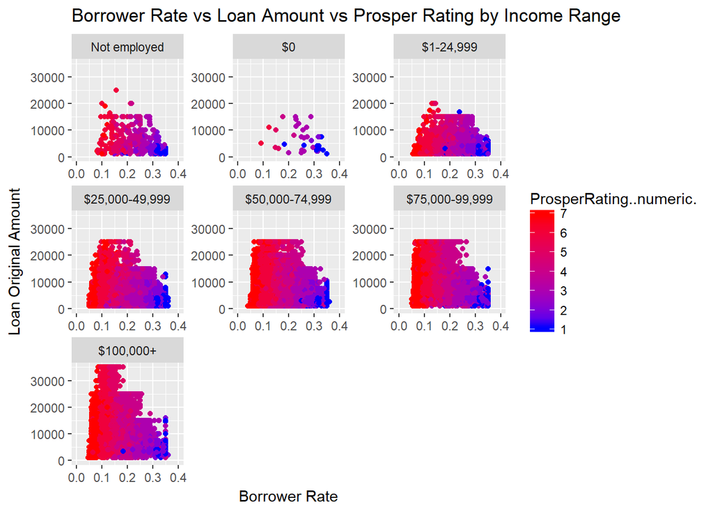

Higher Income Range and Higher Prosper Rating relates to Lower Borrower Rate. Large Income Range means more loans with higher amount. We can observe that as Risk is Lower for lower Rates.

**Borrower Rate / Income Range by Is Borrower Homeowner**

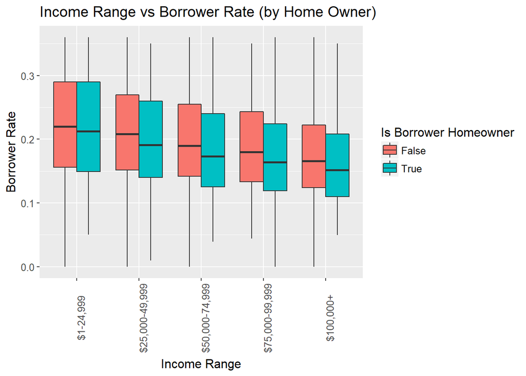

Borrowers with Higher Income who are Home Owners as well have Lower Borrowing Rates.

**Borrower Rate / Loan Amount / Prosper Score**

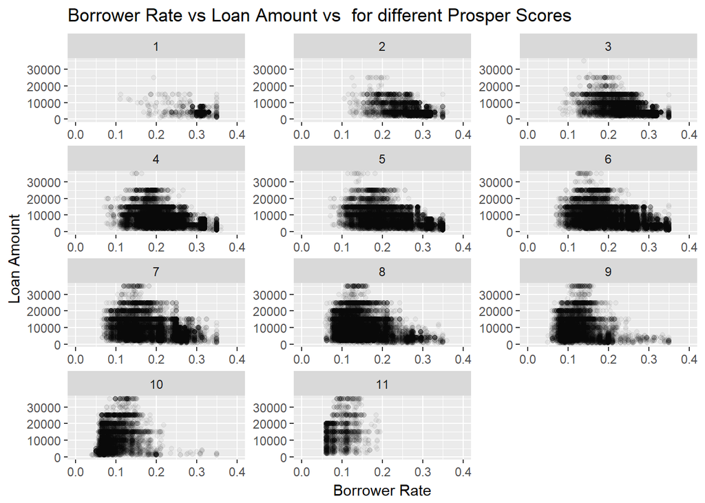

```
##    Min. 1st Qu.  Median    Mean 3rd Qu.    Max.    NA's
##    1.00    4.00    6.00    5.95    8.00   11.00   29084
```

Higher Prosper Score leads to Lower Borrower rate.